# Differing Concentration of AirBnb locations and Effect of Nightly Rate on Multiple Variables

Edward Chang, Ben Draper, Joanne (In Sol) Jun, David Smith

May 7, 2019

# Introduction

# Description of Data

```
##             city                   neighborhood      property_type
##  Oakland      : 834   Mission            : 199   Apartment  :1370
##  San Francisco:2158   Western Addition   : 176   House      : 644
##                       Castro/Upper Market: 147   Guest suite: 406
##                       South of Market    : 145   Condominium: 250
##                       Noe Valley         : 121   Guesthouse : 122
##                       Haight Ashbury     : 120   Loft       :  46
##                       (Other)            :2084   (Other)    : 154
##     latitude       longitude      max_occupancy      bathrooms
##  Min.   :37.71   Min.   :-122.5   Min.   : 1.000   Min.   :0.000
##  1st Qu.:37.76   1st Qu.:-122.4   1st Qu.: 2.000   1st Qu.:1.000
##  Median :37.78   Median :-122.4   Median : 4.000   Median :1.000
##  Mean   :37.78   Mean   :-122.4   Mean   : 3.896   Mean   :1.287
##  3rd Qu.:37.80   3rd Qu.:-122.3   3rd Qu.: 5.000   3rd Qu.:1.500
##  Max.   :37.86   Max.   :-122.1   Max.   :16.000   Max.   :5.000
##
##     bedrooms      nightly_rate    number_of_reviews avg_review_score
##  Min.   :0.000   Min.   :  10.0   Min.   :  1.00    Min.   : 20.00
##  1st Qu.:1.000   1st Qu.: 120.0   1st Qu.:  5.00    1st Qu.: 94.00
##  Median :1.000   Median : 160.0   Median : 20.00    Median : 97.00
##  Mean   :1.508   Mean   : 220.9   Mean   : 50.08    Mean   : 95.35
##  3rd Qu.:2.000   3rd Qu.: 249.0   3rd Qu.: 69.00    3rd Qu.:100.00
##  Max.   :9.000   Max.   :1850.0   Max.   :602.00    Max.   :100.00
##
```

#Topic 1: Distribution of AirBnb Listings

[figure not shown]

Based on the first map of the locations of the listings in this data set, the density of listings in San Francisco is considerably higher than that of Oakland’s. There seems to be less spread in the distribution of listings in San Francisco and this may be due to the preferred neighborhoods of AirBnb customers influencing an owner’s choice to start a listing. In Oakland, it appears that the latter also applies, however, there is a larger spread of listings; there are some areas of high concentration, however the majority of locations seem to be in various spots.

In the second map, the concentration of the listings seem to correspond to that of the previous map. (Although we do not have an exact number of bookings for each listing, the assumption that the number of reviews is proportional to the number of bookings is being used for this analysis.) This visual seems to provide evidence that there are preferred locations without regard to the problem with each listings length of operation. Ignoring that problem, removing the lesser booked listings eliminates some probability of the distributions of the listing just happening to be concentrated in those areas; there is now a visualization that there is more demand for listings in those areas because they have more reviews.

The centers of listing concentration for based on the two maps seem to be similar to each other, supporting that that there is a greater demand for listings in those specific neighborhoods or areas. To further this conclusion that the distribution is not random, a chi squared goodness of fitness test based on the frequency of listings per neighborhood will be performed (doing this per neighborhood provides a basis for grouping of listings).

##### Chi Squared Goodness of Fit Test on the Frequency of listings per neighborhood

A chi squared goodness of fit test will be able to conclude if the frequency of listings per neighborhood is due to chance or if some other factor is affecting it. To perform this test, we will proceed with two hypotheses:  
The null hypothesis that the frequency of the listings per neighborhood is due to chance and that they are distributed equally, and the alternative hypothesis that the frequency of the listings per neighborhood is not due to chance and that they are not distributed equally. The p-value for such a hypothesis test is:

```
## [1] Using chisq.test method:
```

```
##
##  Chi-squared test for given probabilities
##
## data:  neighborhoodobs
## X-squared = 7932.9, df = 138, p-value < 2.2e-16
```

```
## [1] Using self-defined/textbook method:
```

```
## [1] X-squared = 7932.87967914439 ,df = 138 ,p-value = 0
```

Since obtained p-value is close to 0, we reject the null hypothesis, therefore we have extremely significant evidence that the frequency of listings per neighborhood is not due to chance and that the listings are not distributed equally. The neighborhoods themselves and some other variables might be affecting the listings neighborhood distributions.  
To analyze these, analyzing other variables’ relationship to the neighborhoods will provide some further insight into what is correlated with or affecting the listing distribution.

##### Chi Squared Goodness of Fit Test on the count of unique neighborhoods per city

Another chi squared goodness of fit test will be performed to determine if the count of unique neighborhoods per city containing listings is due to chance. This test will use the following hypotheses:  
the null hypothesis that the count of unique neighborhoods per city is due to chance, each city has the same count of unique neighborhoods, and that the city has no effect on the count of unique neighborhoods; and  
the alternative hypothesis that the count of unique neighborhoods per city is not due to chance, the count of unique neighborhoods is not the same in the cities, and that the city or some other variable has an effect on the count of unique neighborhoods.

```
## [1] Using chisq.test method:
```

```
##
##  Chi-squared test for given probabilities
##
## data:  city_counts
## X-squared = 34.507, df = 1, p-value = 4.247e-09
```

```
## [1] Using self-defined/textbook method:
```

```
## [1] X-squared = 34.5070422535211 ,df = 1 ,p-value = 4.24711942504783e-09
```

#### Edward Chang (plots and descriptions for topic 1)

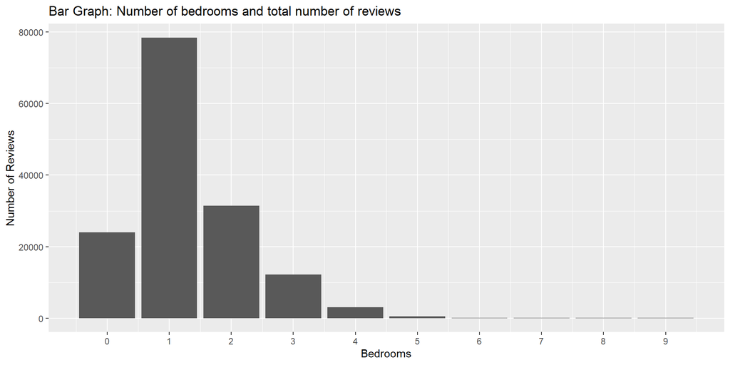

[figure not shown]

This bar graph plots the number of bedrooms against the total number of reviews that such listings have received. The graph is right skewed and spikes at 1, indicating that the a majority of customers book listings with 0, 1, or 2 bedroom(s). This means that there is a greater demand for listings with these amount of bedrooms. The areas with great concentration of listings should have bedrooms with such numbers. To check this, a map can be plotted, filtering the listings by 0, 1, or 2 bedrooms(s) and compare this with a plot of the rest of the bedroom counts.  
This filtering of bedrooms in Maps 3 and 4 visualizes the drastic change in centers of concentration. In Map 3, the centers of concentration are very similar to that of Map 1’s, which indicates that there was a strong influence of 0, 1, or 2 bedroom listings on the distribution of listings. On the other hand, Map 4’s centers of concentrations are slightly off in San Francisco and very inaccurate in Oakland. As we can see from these maps, the number of bedrooms is related to the distribution of listings.

#### David Smith (Plot and Description for Topic 1)

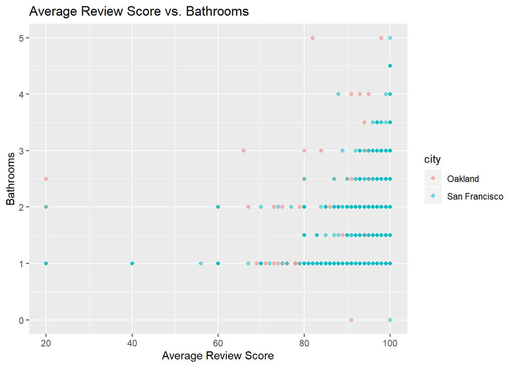

I analyzed the data to see if there was any correlation between the amount of bathrooms and the average review score for the Airbnb. In Oakland, there seems to be a slight correlation between more bathrooms and a higher score. This could denote maybe a better house or living situation in these homes. In San Francisco, however, the data seems to be spread evenly, with high ratings throughout the bathroom spread. In Oakland there is slight correlation with more bathrooms and a higher score, but in San Francisco, this is not the case.

# Topic 2: Effects of Nighly Rate on Multiple Variables

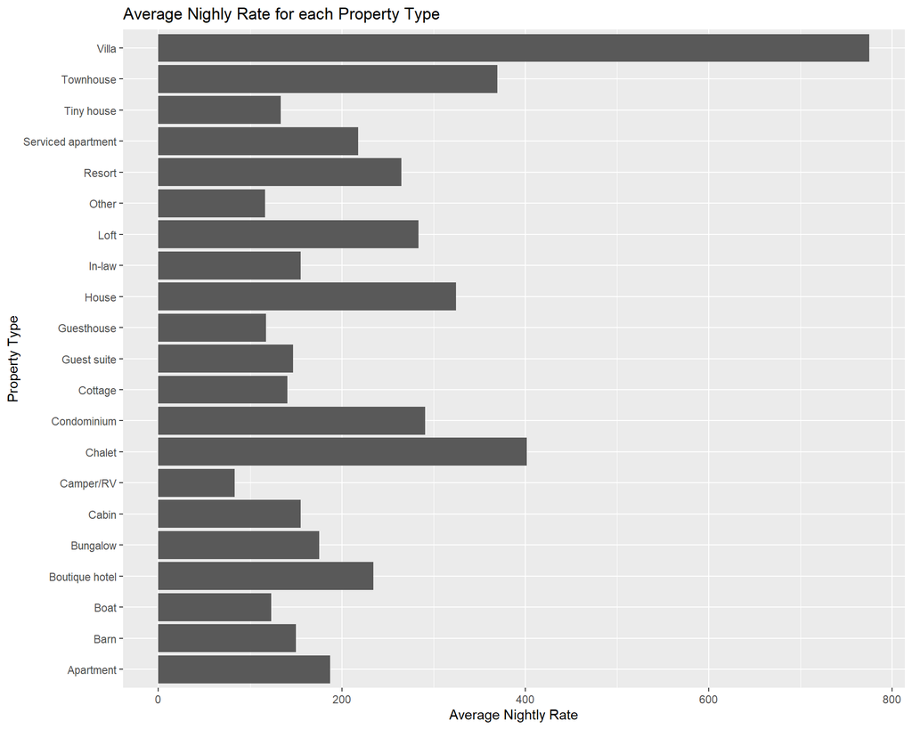

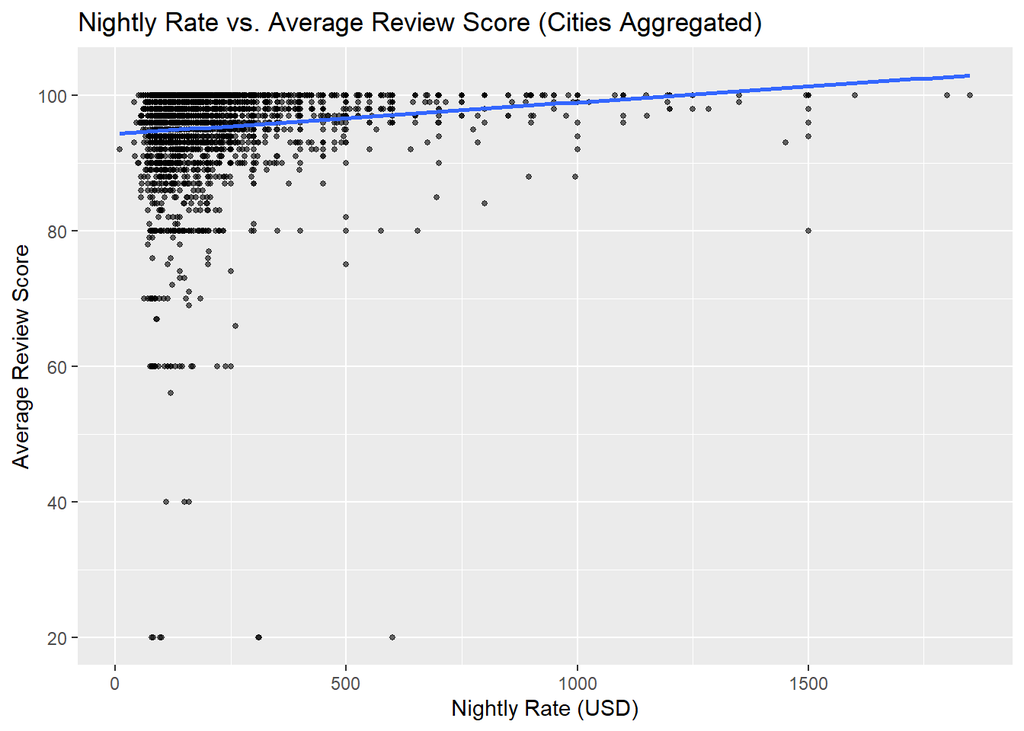

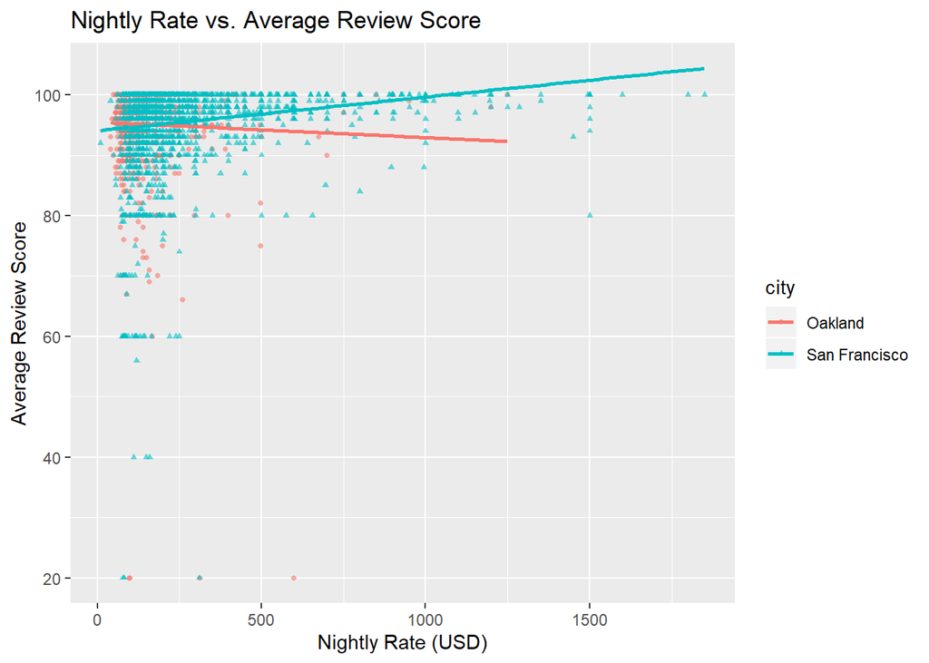

After plotting the regression lines of nightly rate vs. average review score for San Francisco, Oakland, and combined data, we observed that combined and SF data had positive slopes whereas Oakland data had slightly negative slope. Due to people’s tendency to pick listings with high rating and low nightly rate, top left corner of all three plots were concentrated. Moreover, because of this reason, the regression line for these plots are not accurate due to the skewed data.

#### Joanne (In Sol) Jun (Plot and Description for Topic 2)

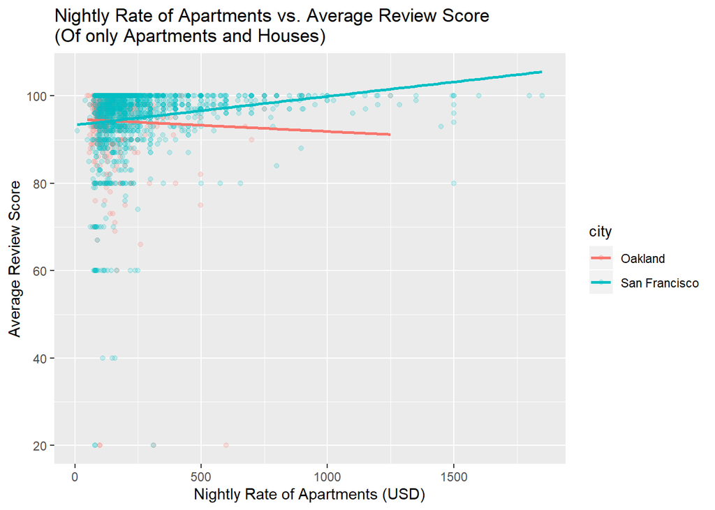

For individual project, I chose to plot two data from Oakland and San Francisco to see differing trend of average review scores based of the nightly rate of apartments between two cities. This plot was particularly interesting to me that as nightly rate of apartments increase, the average review score for San Francisco tend to increase, whereas score for Oakland decreased. I believe that this shows how people tend to have high expectation for the apartments with high nightly rates for both cities; however, listings in Oakland with high nightly rate do not seem to fulfill those expectations. The limitation of this plot was that review scores of the listings in Oakland with high nightly rates lack which didn’t sufficiently supported the regression line.

#### Ben Draper (Plot and Description for Topic 2)

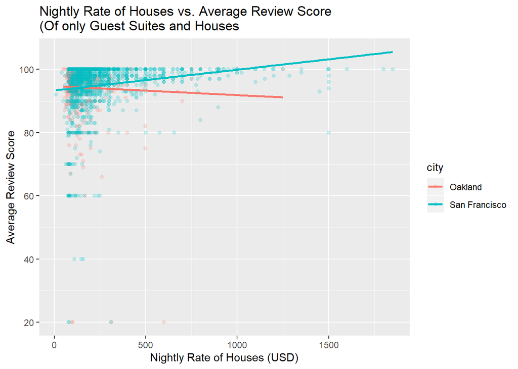

I studied the differences between the average review between houses in San Francisco and Oakland. The data shows that houses in San Francisco have a higher review than houses in Oakland. Houses in San Francisco may have a higher review score because of their proximity to one of the biggest tourist cities in the World. This shows that location does have an impact on reviews given to houses on AirBnb.

##### Regression Line Hypothesis Testing on San Francisco nightly rate vs average review score

[output not shown]

```
##
## Call:
## lm(formula = y1 ~ x1)
##
## Residuals:
##     Min      1Q  Median      3Q     Max
## -75.791  -1.436   1.974   4.117   5.606
##
## Coefficients:
##              Estimate Std. Error t value Pr(>|t|)
## (Intercept) 9.406e+01  2.396e-01 392.619  < 2e-16 ***
## x1          5.590e-03  7.409e-04   7.545 6.65e-14 ***
## ---
## Signif. codes:  0 '***' 0.001 '**' 0.01 '*' 0.05 '.' 0.1 ' ' 1
##
## Residual standard error: 7.142 on 2156 degrees of freedom
## Multiple R-squared:  0.02572,    Adjusted R-squared:  0.02527
## F-statistic: 56.92 on 1 and 2156 DF,  p-value: 6.646e-14
```

##### Regression Line Hypothesis Testing on Oakland nightly rate vs average review score

[output not shown]

```
##
## Call:
## lm(formula = y2 ~ x2)
##
## Residuals:
##     Min      1Q  Median      3Q     Max
## -75.256  -1.233   1.808   3.854   7.693
##
## Coefficients:
##              Estimate Std. Error t value Pr(>|t|)
## (Intercept) 95.503983   0.436367 218.862   <2e-16 ***
## x2          -0.002560   0.002317  -1.105     0.27
## ---
## Signif. codes:  0 '***' 0.001 '**' 0.01 '*' 0.05 '.' 0.1 ' ' 1
##
## Residual standard error: 7.534 on 832 degrees of freedom
## Multiple R-squared:  0.001465,   Adjusted R-squared:  0.0002649
## F-statistic: 1.221 on 1 and 832 DF,  p-value: 0.2695
```

### Reference(s):

1. https://www.bestplaces.net/compare-cities/san_francisco_ca/oakland_ca/economy